# Part 1 - Intro to the gRammar of gRaphics with `ggplot2`

Chester Ismay

In this section, we’ll discuss the Grammar of Graphics developed by [Leland Wilkinson](http://www.powells.com/book/the-grammar-of-graphics-9780387245447) and implemented in R via [Hadley Wickham](http://www.powells.com/book/ggplot2-elegant-graphics-for-data-analysis-9783319242750/68-428). We’ll see how this is applied to a scatterplot with and without a regression line. These ideas will then be extended in Part 2 of the workshop.

### The Grammar of Graphics

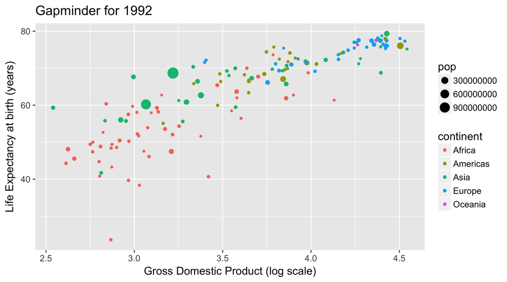

- What are the variables here?
- What is the observational unit?
  - i.e., what is the THING being measured?
- How are the variables mapped to aesthetics?

## What is a statistical graphic?

### A `mapping` of `data` variables

### to `aes()`thetic attributes

### of `geom_`etric objects.

**Back to basics**

Consider the following data in tidy format:

```r
simple_ex <-
  data_frame(
    A = c(1980, 1990, 2000, 2010),
    B = c(1, 2, 4, 5),
    C = c(3, 2, 1, 2),
    D = c("low", "low", "high", "high")
  )
simple_ex
```

```
# A tibble: 4 x 4
      A     B     C     D
  <dbl> <dbl> <dbl> <chr>
1  1980     1     3   low
2  1990     2     2   low
3  2000     4     1  high
4  2010     5     2  high
```

- Sketch the graphics below on paper, where the `x`-axis is variable `A` and the `y`-axis is variable `B`
1. A scatterplot
2. A scatterplot with fitted least-squares regression line

Intermediate folks:

- 3. A scatter plot where the `color` of the points corresponds to `D` and the `size` of the points corresponds to `C`
- 4. Only show a regression line of color “goldenrod” (no points and also no error bounds)
1. A scatterplot

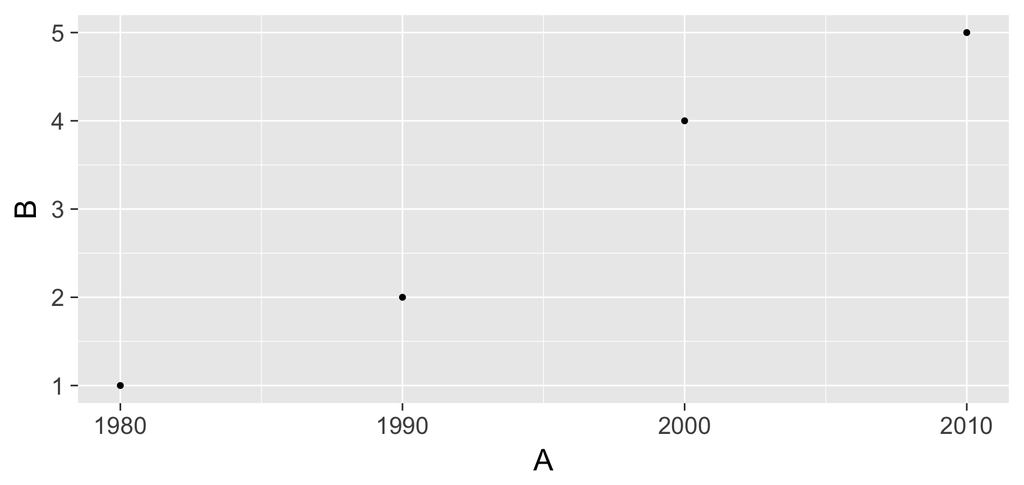

```r
ggplot(data = simple_ex, mapping = aes(x = A, y = B)) +
  geom_point()
```

2. A scatterplot with fitted least-squares regression line

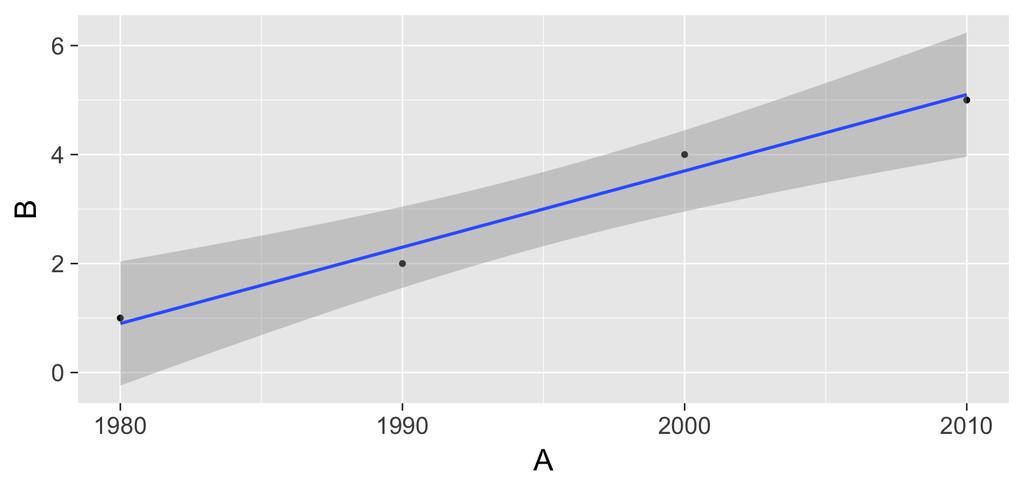

```r
ggplot(data = simple_ex, mapping = aes(x = A, y = B)) +
  geom_point() +
  geom_smooth(method = "lm")
```

**Intermediate**

3. A scatter plot where the `color` of the points corresponds to `D` and the `size` of the points corresponds to `C`

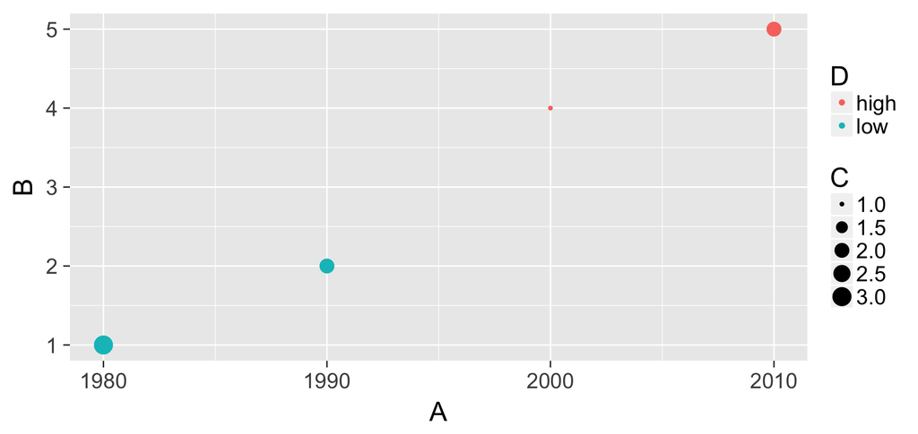

```r
ggplot(data = simple_ex, mapping = aes(x = A, y = B)) +
  geom_point(mapping = aes(color = D, size = C))
```

4. Only show a regression line of color “goldenrod” (no points and also no error bounds)

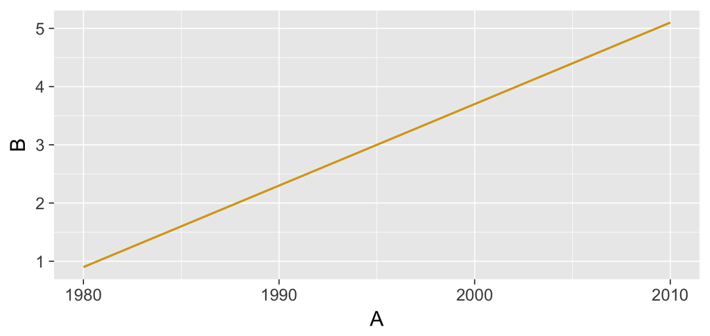

```r
ggplot(data = simple_ex, mapping = aes(x = A, y = B)) +
  geom_smooth(method = "lm", se = FALSE, color = "goldenrod")
```

## Your Task

Recreate the gapminder plot shown at the beginning of this workshop (and below) using `ggplot2` and the `gapminder` data frame in the `gapminder` package. The [Data Visualization Cheat Sheet](https://www.rstudio.com/wp-content/uploads/2016/11/ggplot2-cheatsheet-2.1.pdf) from RStudio may be helpful.

**Note**: To focus on only the rows in the data frame corresponding to 1992 we use the `filter` function from `dplyr` that we will discuss in Part 3 of this workshop.

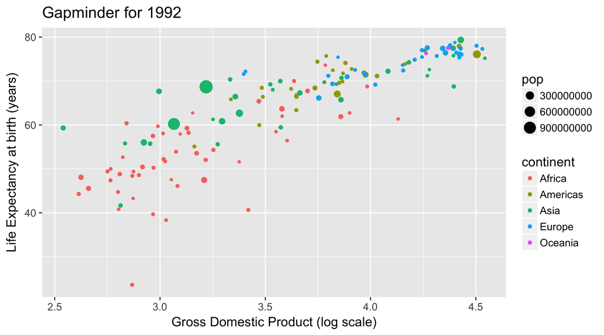

```r
library(gapminder)
gap1992 <- gapminder %>% filter(year == 1992)

#Space for your answer here.
```